# Project: Medical No Show Appointments Data Analysis

- Introduction
- Data Wrangling
- Exploratory Data Analysis
  - Data Overview
  - Research Question 1: Does the number of SMS received by the patient affects the show-up probability?
  - Research Question 2: Does the day of week affect patient no-show rate?
  - Research Question 3: Does the gap between scheduled date and appointment date affect patient no-show rate?
- Conclusions

```python
import pandas as pd
import matplotlib.pyplot as plt
import numpy as np
import re
%matplotlib inline
```

## Introduction

In this dataset, I will analyze the Medical Appointment No Show dataset from Kaggle ([link to dataset](https://www.kaggle.com/joniarroba/noshowappointments)).  
My analysis will answer the following questions:

- Does the number of SMS received by the patient affects the show-up probability?
- Does the day of week affect patient no-show rate?
- Does the gap between scheduled date and appointment date affect patient no-show rate?

## Data Wrangling

### Loading Data

Below I will load the data and show the first rows of the data and the information about each columns of the data.

```python
filename = 'data/noshowappointments-kagglev2-may-2016.csv'

df = pd.read_csv(filename)
```

### Fixing Column Names

First let's see the column names:

```python
df.columns
```

```
Index(['PatientId', 'AppointmentID', 'Gender', 'ScheduledDay',
       'AppointmentDay', 'Age', 'Neighbourhood', 'Scholarship', 'Hipertension',
       'Diabetes', 'Alcoholism', 'Handcap', 'SMS_received', 'No-show'],
      dtype='object')
```

Firstly we can look at the column names. As you can see, they are in camel case, and one of the column has "-" instead of "_". So first I'll fix the column names to be python friendly by:

- converting "-" to be "_"
- converting the column names to snake case and lower case using regex

```python
# correct the column names to be snake case
df.rename(columns=lambda x: x.replace('-', '_'), inplace=True)
df.rename(columns=lambda x: re.sub(r'(?<!^)(?=[A-Z])', '_', x).lower(), inplace=True)
```

Now let's see the column names:

```python
df.columns
```

```
Index(['patient_id', 'appointment_i_d', 'gender', 'scheduled_day',
       'appointment_day', 'age', 'neighbourhood', 'scholarship',
       'hipertension', 'diabetes', 'alcoholism', 'handcap', 's_m_s_received',
       'no_show'],
      dtype='object')
```

As you can see above, some camel case column names are converted wrongly like the "ID" becomes "i_d" and "SMS" becomes "s_m_s". So I'll fix them to be "id" and "sms" below.

```python
df.rename(columns=lambda x: x.replace('s_m_s', 'sms'), inplace=True)
df.rename(columns=lambda x: x.replace('i_d', 'id'), inplace=True)
```

Now the column names have been fixed to be:

```python
df.columns
```

```
Index(['patient_id', 'appointment_id', 'gender', 'scheduled_day',
       'appointment_day', 'age', 'neighbourhood', 'scholarship',
       'hipertension', 'diabetes', 'alcoholism', 'handcap', 'sms_received',
       'no_show'],
      dtype='object')
```

Lastly if you notice, one of the column names is `handcap`, which I believe is a typo. I'll correct the name to be `handicap`.

```python
df.rename(columns={'handcap': 'handicap'}, inplace=True)
```

```python
df.columns
```

```
Index(['patient_id', 'appointment_id', 'gender', 'scheduled_day',
       'appointment_day', 'age', 'neighbourhood', 'scholarship',
       'hipertension', 'diabetes', 'alcoholism', 'handicap', 'sms_received',
       'no_show'],
      dtype='object')
```

### Fixing Column Data Types

Now we'll move on to fixing the column types of the data. Below I'll show the data types of each column.

```python
df.head()
```

|  | patient_id | appointment_id | gender | scheduled_day | appointment_day | age | neighbourhood | scholarship | hipertension | diabetes | alcoholism | handicap | sms_received | no_show |
| --- | --- | --- | --- | --- | --- | --- | --- | --- | --- | --- | --- | --- | --- | --- |
| 0 | 2.987250e+13 | 5642903 | F | 2016-04-29T18:38:08Z | 2016-04-29T00:00:00Z | 62 | JARDIM DA PENHA | 0 | 1 | 0 | 0 | 0 | 0 | No |
| 1 | 5.589978e+14 | 5642503 | M | 2016-04-29T16:08:27Z | 2016-04-29T00:00:00Z | 56 | JARDIM DA PENHA | 0 | 0 | 0 | 0 | 0 | 0 | No |
| 2 | 4.262962e+12 | 5642549 | F | 2016-04-29T16:19:04Z | 2016-04-29T00:00:00Z | 62 | MATA DA PRAIA | 0 | 0 | 0 | 0 | 0 | 0 | No |
| 3 | 8.679512e+11 | 5642828 | F | 2016-04-29T17:29:31Z | 2016-04-29T00:00:00Z | 8 | PONTAL DE CAMBURI | 0 | 0 | 0 | 0 | 0 | 0 | No |
| 4 | 8.841186e+12 | 5642494 | F | 2016-04-29T16:07:23Z | 2016-04-29T00:00:00Z | 56 | JARDIM DA PENHA | 0 | 1 | 1 | 0 | 0 | 0 | No |

```python
df.info()
```

```
<class 'pandas.core.frame.DataFrame'>
RangeIndex: 110527 entries, 0 to 110526
Data columns (total 14 columns):
 #   Column           Non-Null Count   Dtype
---  ------           --------------   -----
 0   patient_id       110527 non-null  float64
 1   appointment_id   110527 non-null  int64
 2   gender           110527 non-null  object
 3   scheduled_day    110527 non-null  object
 4   appointment_day  110527 non-null  object
 5   age              110527 non-null  int64
 6   neighbourhood    110527 non-null  object
 7   scholarship      110527 non-null  int64
 8   hipertension     110527 non-null  int64
 9   diabetes         110527 non-null  int64
 10  alcoholism       110527 non-null  int64
 11  handicap         110527 non-null  int64
 12  sms_received     110527 non-null  int64
 13  no_show          110527 non-null  object
dtypes: float64(1), int64(8), object(5)
memory usage: 11.8+ MB
```

As you can see in the info above, there are some interesting aspects to be fixed, summarized in below points:

- `patient_id` and `appointment_id` are both of float and integer types. However, they are actually just for identification, and the quantity of the numbers have no actual significance (one ID is not "higher" than the other ID). So in this case I'll convert those columns to be string instead.
- `scheduled_day` and `appointment_day` are all in string type, while actually they are datetime. So I'll convert those columns into datetime.
- For `scholarship`, `hipertension`, `diabetes`, and `alcoholism`, the description of the dataset ([link to dataset](https://www.kaggle.com/joniarroba/noshowappointments)) explains that those columns are of boolean type. So I'll convert them to be boolean.
- As for `handicap` and `sms_received`, they're rather special and will be processed in the next cells. In summary, I'll swap both values of the columns and convert the column `handicap` to be boolean, while the column `sms_received` stays as integer.
- `no_show` column will be converted into boolean as well, and will be converted into `show_up` column (where the original values will be converted), as this new column will be more intuitive.

#### Converting `patient_id` and `appointment_id`

First to be safe, let's check for duplicate values of these columns

```python
print(f' Number of duplicated patient_id: {sum(df.patient_id.duplicated())}')
print(f' Number of duplicated appointment_id: {sum(df.appointment_id.duplicated())}')
```

```
 Number of duplicated patient_id: 48228
 Number of duplicated appointment_id: 0
```

Duplicated `patient_id` is expected because one patient can have multiple appointments.  
There is no duplicated `appointment_id`, which is good and as expected, because each appointment must have unique ID.

Now we'll move on to convert those columns to be string:

```python
# casting to int64 is needed so that the resulting string does not contain the decimal points
df.patient_id = df.patient_id.astype('int64').astype(str)
df.appointment_id = df.appointment_id.astype(str)
```

```python
df.head()[['patient_id', 'appointment_id']]
```

|  | patient_id | appointment_id |
| --- | --- | --- |
| 0 | 29872499824296 | 5642903 |
| 1 | 558997776694438 | 5642503 |
| 2 | 4262962299951 | 5642549 |
| 3 | 867951213174 | 5642828 |
| 4 | 8841186448183 | 5642494 |

```python
df[['patient_id', 'appointment_id']].info()
```

```
<class 'pandas.core.frame.DataFrame'>
RangeIndex: 110527 entries, 0 to 110526
Data columns (total 2 columns):
 #   Column          Non-Null Count   Dtype
---  ------          --------------   -----
 0   patient_id      110527 non-null  object
 1   appointment_id  110527 non-null  object
dtypes: object(2)
memory usage: 1.7+ MB
```

The info above now confirms that the `patient_id` and `appointment_id` are now of string type.

#### Converting `scheduled_day` and `appointment_day`

First let's check whether their values are of correct datetime format.

```python
df[['scheduled_day', 'appointment_day']].head()
```

|  | scheduled_day | appointment_day |
| --- | --- | --- |
| 0 | 2016-04-29T18:38:08Z | 2016-04-29T00:00:00Z |
| 1 | 2016-04-29T16:08:27Z | 2016-04-29T00:00:00Z |
| 2 | 2016-04-29T16:19:04Z | 2016-04-29T00:00:00Z |
| 3 | 2016-04-29T17:29:31Z | 2016-04-29T00:00:00Z |
| 4 | 2016-04-29T16:07:23Z | 2016-04-29T00:00:00Z |

The format looks good. I'll then proceed to convert them into datetime:

```python
df.scheduled_day = pd.to_datetime(df.scheduled_day, infer_datetime_format=True)
df.appointment_day = pd.to_datetime(df.appointment_day, infer_datetime_format=True)
```

```python
df[['scheduled_day', 'appointment_day']].head()
```

|  | scheduled_day | appointment_day |
| --- | --- | --- |
| 0 | 2016-04-29 18:38:08 | 2016-04-29 |
| 1 | 2016-04-29 16:08:27 | 2016-04-29 |
| 2 | 2016-04-29 16:19:04 | 2016-04-29 |
| 3 | 2016-04-29 17:29:31 | 2016-04-29 |
| 4 | 2016-04-29 16:07:23 | 2016-04-29 |

```python
df[['scheduled_day', 'appointment_day']].info()
```

```
<class 'pandas.core.frame.DataFrame'>
RangeIndex: 110527 entries, 0 to 110526
Data columns (total 2 columns):
 #   Column           Non-Null Count   Dtype
---  ------           --------------   -----
 0   scheduled_day    110527 non-null  datetime64[ns]
 1   appointment_day  110527 non-null  datetime64[ns]
dtypes: datetime64[ns](2)
memory usage: 1.7 MB
```

An interesting finding from the conversion result is on `appointment_day`. It seems that the values of the column are all having time 00:00:00. This makes sense, because the column's purpose is to show the day of the appointment, and not the time. Nonetheless, the info above confirms that now the columns are of datetime type.

#### Converting `scholarship`, `hipertension`, `diabetes`, and `alcoholism`

To be safe, first I'll check the columns' unique values.

```python
print(f'"scholarship" unique values: {df.scholarship.unique()}')
print(f'"hipertension" unique values: {df.hipertension.unique()}')
print(f'"diabetes" unique values: {df.diabetes.unique()}')
print(f'"alcoholism" unique values: {df.alcoholism.unique()}')
```

```
"scholarship" unique values: [0 1]
"hipertension" unique values: [1 0]
"diabetes" unique values: [0 1]
"alcoholism" unique values: [0 1]
```

As you can see above, all of them are only of values 1's and 0's, so they are safe to be converted into boolean. What I mean by safe is: safe to be converted into boolean without altering the meaning of the columns. This point is crucial when we're dealing with the `handicap` and `sms_received` columns in the next section. I'll then convert them into boolean below.

```python
df.scholarship = df.scholarship.astype(bool)
df.hipertension = df.hipertension.astype(bool)
df.diabetes = df.diabetes.astype(bool)
df.alcoholism = df.alcoholism.astype(bool)
```

```python
df[['scholarship', 'hipertension', 'diabetes', 'alcoholism']].head()
```

|  | scholarship | hipertension | diabetes | alcoholism |
| --- | --- | --- | --- | --- |
| 0 | False | True | False | False |
| 1 | False | False | False | False |
| 2 | False | False | False | False |
| 3 | False | False | False | False |
| 4 | False | True | True | False |

```python
df[['scholarship', 'hipertension', 'diabetes', 'alcoholism']].info()
```

```
<class 'pandas.core.frame.DataFrame'>
RangeIndex: 110527 entries, 0 to 110526
Data columns (total 4 columns):
 #   Column        Non-Null Count   Dtype
---  ------        --------------   -----
 0   scholarship   110527 non-null  bool
 1   hipertension  110527 non-null  bool
 2   diabetes      110527 non-null  bool
 3   alcoholism    110527 non-null  bool
dtypes: bool(4)
memory usage: 431.9 KB
```

The info above confirms that those columns are now of type boolean.

#### Processing `handicap` and `sms_received`

I assumed that `handicap` and `sms_received` columns were swapped by each other. Below I'll show you the reason why. First let's see the unique values of both columns.

```python
print(f'"handicap" unique values: {df.handicap.unique()}')
print(f'"sms_received" unique values: {df.sms_received.unique()}')
```

```
"handicap" unique values: [0 1 2 3 4]
"sms_received" unique values: [0 1]
```

As you can see above, `handicap` values consists of integers from 0 to 4, whereas values of `sms_received` is only 1 or 0. However, in the dataset description, it says that `handicap` is boolean value of whether the patient is handicapped or not, whereas `sms_received` is the number of messages received by the patient. The actual values, however, shows that the nature of `handicap` suits better for integer, whereas `sms_received` suits better for boolean, which is not what is expected from the dataset description. In this case, since those columns are next to each other, I believe that they're swapped by the creator of the dataset.

Based on the observation above, I'll then swap their values by simply renaming the columns.

```python
df.rename(columns={'handicap': 'sms_received', 'sms_received': 'handicap'}, inplace=True)
```

```python
print(f'"handicap" unique values: {df.handicap.unique()}')
print(f'"sms_received" unique values: {df.sms_received.unique()}')
```

```
"handicap" unique values: [0 1]
"sms_received" unique values: [0 1 2 3 4]
```

The above print shows that now they are properly swapped. I'll then convert the `handicap` column to be boolean.

```python
df.handicap = df.handicap.astype(bool)
```

```python
df[['handicap', 'sms_received']].info()
```

```
<class 'pandas.core.frame.DataFrame'>
RangeIndex: 110527 entries, 0 to 110526
Data columns (total 2 columns):
 #   Column        Non-Null Count   Dtype
---  ------        --------------   -----
 0   handicap      110527 non-null  bool
 1   sms_received  110527 non-null  int64
dtypes: bool(1), int64(1)
memory usage: 971.6 KB
```

The info above now shows that `handicap` is correctly typed as boolean, and `sms_received` stays as integer.

#### Converting `no_show` into `show_up`

Firstly I'll convert the `no_show` column into boolean, then I'll convert the column to be a `show_up` column (with all the original boolean values inverted) to have a column that says whether the patient shows up for the appointment or not. I believe this new `show_up` column is more intuitive.

To be safe, I'll first ensure that the unique values of `no_show` is safe to be converted into boolean.

```python
print(f'"no_show" unique values: {df.no_show.unique()}')
```

```
"no_show" unique values: ['No' 'Yes']
```

Now we can see that `no_show` only consists of values 'Yes' or 'No', so it is safe to convert the column into boolean.

```python
df.no_show = df.no_show.apply(lambda x: x == 'Yes')
```

```python
print(f'"no_show" unique values: {df.no_show.unique()}')
```

```
"no_show" unique values: [False  True]
```

```python
df.no_show.dtype
```

```
dtype('bool')
```

The above prints show that now the `no_show` column are correctly of type boolean. I'll then now proceed to convert this column into `show_up` column, where I'll invert the original boolean values.

```python
df['show_up'] = ~df.no_show
```

```python
df[['no_show', 'show_up']].head()
```

|  | no_show | show_up |
| --- | --- | --- |
| 0 | False | True |
| 1 | False | True |
| 2 | False | True |
| 3 | False | True |
| 4 | False | True |

As you can see above, the value of the `show_up` is correctly calculated from the `no_show` column. I'll now drop the `no_show` column as it is no longer useful.

```python
df.drop(columns='no_show', inplace=True)
```

```python
df.columns
```

```
Index(['patient_id', 'appointment_id', 'gender', 'scheduled_day',
       'appointment_day', 'age', 'neighbourhood', 'scholarship',
       'hipertension', 'diabetes', 'alcoholism', 'sms_received', 'handicap',
       'show_up'],
      dtype='object')
```

The above print confirms that the column `no_show` has been removed.

#### Remaining columns...

For the remaining columns which are `gender`, `age`, and `neighbourhood`, their data types already matches their purpose, so they're good to go.

#### Column Data Types Conclusion

This concludes the column data types processing. Below I'll show the final state of the column data types, and their values.

```python
df.head()
```

|  | patient_id | appointment_id | gender | scheduled_day | appointment_day | age | neighbourhood | scholarship | hipertension | diabetes | alcoholism | sms_received | handicap | show_up |
| --- | --- | --- | --- | --- | --- | --- | --- | --- | --- | --- | --- | --- | --- | --- |
| 0 | 29872499824296 | 5642903 | F | 2016-04-29 18:38:08 | 2016-04-29 | 62 | JARDIM DA PENHA | False | True | False | False | 0 | False | True |
| 1 | 558997776694438 | 5642503 | M | 2016-04-29 16:08:27 | 2016-04-29 | 56 | JARDIM DA PENHA | False | False | False | False | 0 | False | True |
| 2 | 4262962299951 | 5642549 | F | 2016-04-29 16:19:04 | 2016-04-29 | 62 | MATA DA PRAIA | False | False | False | False | 0 | False | True |
| 3 | 867951213174 | 5642828 | F | 2016-04-29 17:29:31 | 2016-04-29 | 8 | PONTAL DE CAMBURI | False | False | False | False | 0 | False | True |
| 4 | 8841186448183 | 5642494 | F | 2016-04-29 16:07:23 | 2016-04-29 | 56 | JARDIM DA PENHA | False | True | True | False | 0 | False | True |

```python
df.info()
```

```
<class 'pandas.core.frame.DataFrame'>
RangeIndex: 110527 entries, 0 to 110526
Data columns (total 14 columns):
 #   Column           Non-Null Count   Dtype
---  ------           --------------   -----
 0   patient_id       110527 non-null  object
 1   appointment_id   110527 non-null  object
 2   gender           110527 non-null  object
 3   scheduled_day    110527 non-null  datetime64[ns]
 4   appointment_day  110527 non-null  datetime64[ns]
 5   age              110527 non-null  int64
 6   neighbourhood    110527 non-null  object
 7   scholarship      110527 non-null  bool
 8   hipertension     110527 non-null  bool
 9   diabetes         110527 non-null  bool
 10  alcoholism       110527 non-null  bool
 11  sms_received     110527 non-null  int64
 12  handicap         110527 non-null  bool
 13  show_up          110527 non-null  bool
dtypes: bool(6), datetime64[ns](2), int64(2), object(4)
memory usage: 7.4+ MB
```

### Fixing Column Values

In this section, I'll explore and fix the values of the columns.

#### Fixing `age` values

Firstly let's analyze the numeric columns.

```python
df.describe()
```

|  | age | sms_received |
| --- | --- | --- |
| count | 110527.000000 | 110527.000000 |
| mean | 37.088874 | 0.022248 |
| std | 23.110205 | 0.161543 |
| min | -1.000000 | 0.000000 |
| 25% | 18.000000 | 0.000000 |
| 50% | 37.000000 | 0.000000 |
| 75% | 55.000000 | 0.000000 |
| max | 115.000000 | 4.000000 |

`sms_received` seems to be good, but `age` column seems to be problematic. The column seems to have minimum value of -1, which does not makes sense. Now let's see the distribution of the value of `age` below.

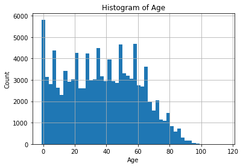

```python
df.age.hist(bins=50)
plt.title('Histogram of Age')
plt.xlabel('Age')
plt.ylabel('Count');
```

There seems to be smooth distribution of the values near 0, so kind of makes sense to have very low values for `age` (for babies for example). This opens the possibility that the -1 age might be fixed to become age of 0. So now let's count how many data there is that have age lower than 0.

```python
print(f'Number of rows with negative valued age: {sum(df.age < 0)}')
```

```
Number of rows with negative valued age: 1
```

There is only one row that has negative `age`, which means this is indeed a noise. To be safe and to avoid any wrong assumption, I'll just drop this single row with negative age.

```python
df.drop(df[df.age < 0].index, inplace=True)
```

Now let's see the new distribution of `age`:

```python
df.age.describe()
```

```
count    110526.000000
mean         37.089219
std          23.110026
min           0.000000
25%          18.000000
50%          37.000000
75%          55.000000
max         115.000000
Name: age, dtype: float64
```

The print shows that we're good to go for `age`. As for the max value of 115, it is indeed possible for a human to be aged 115 years, because the oldest human in the world now is 122 years!

#### Confirming validity of `gender`

Firstly, let's check the `gender` unique values.

```python
print(f'"gender" unique values: {df.gender.unique()}')
```

```
"gender" unique values: ['F' 'M']
```

The `gender` column has only the unique values shown above, which is valid and has no surprises.

#### Confirming validity of `neighbourhood`

As for `neighbourhood`, let's see the unique values as well. Also, we'll sort the values to check for possible typo (any typo will have more or less similar value, so sorting might help).

```python
neighbourhood_values = df.neighbourhood.unique()
neighbourhood_values.sort()
print('\n'.join(neighbourhood_values))
```

```
AEROPORTO
ANDORINHAS
ANTÔNIO HONÓRIO
ARIOVALDO FAVALESSA
BARRO VERMELHO
BELA VISTA
BENTO FERREIRA
BOA VISTA
BONFIM
CARATOÍRA
CENTRO
COMDUSA
CONQUISTA
CONSOLAÇÃO
CRUZAMENTO
DA PENHA
DE LOURDES
DO CABRAL
DO MOSCOSO
DO QUADRO
ENSEADA DO SUÁ
ESTRELINHA
FONTE GRANDE
FORTE SÃO JOÃO
FRADINHOS
GOIABEIRAS
GRANDE VITÓRIA
GURIGICA
HORTO
ILHA DAS CAIEIRAS
ILHA DE SANTA MARIA
ILHA DO BOI
ILHA DO FRADE
ILHA DO PRÍNCIPE
ILHAS OCEÂNICAS DE TRINDADE
INHANGUETÁ
ITARARÉ
JABOUR
JARDIM CAMBURI
JARDIM DA PENHA
```

[output cut: 26 more lines]

```
SANTA MARTHA
SANTA TEREZA
SANTO ANDRÉ
SANTO ANTÔNIO
SANTOS DUMONT
SANTOS REIS
SEGURANÇA DO LAR
SOLON BORGES
SÃO BENEDITO
SÃO CRISTÓVÃO
SÃO JOSÉ
SÃO PEDRO
TABUAZEIRO
UNIVERSITÁRIO
VILA RUBIM
```

There seems to be no obvious typo from the values of the `neighbourhood`. One last check is to see the value with the minimum count, which might show typo as well.

```python
df.neighbourhood.value_counts().idxmin()
```

```
'PARQUE INDUSTRIAL'
```

As you can see, the value with minimum count seems to be a valid value, showing that no typo occurs in this column. Hence, this column is good to go.

#### `patient_id` and `appointment_id`

A simple duplicated value check will be done for these columns.

```python
print(f'Number of duplicated patient_id: {sum(df.patient_id.duplicated())}')
print(f'Number of duplicated appointment_id: {sum(df.appointment_id.duplicated())}')
```

```
Number of duplicated patient_id: 48228
Number of duplicated appointment_id: 0
```

There is no duplicate values for `appointment_id` which is good and expected. Duplicated values for `patient_id` is expected because one patient can have many appointments.

#### `scheduled_day` and `appointment_day`

It'll be interesting to see any data that has `scheduled_day` being later than the `appointment_day`, which will be invalid. But note that we'll check only for the date, and will not care about the time, because the `appointment_day` does not have time information.

```python
scheduled_later = df.scheduled_day.dt.date > df.appointment_day.dt.date
print(f'Number of rows that has scheduled_day date > appointment_day: {sum(scheduled_later)}')
```

```
Number of rows that has scheduled_day date > appointment_day: 5
```

```python
df[scheduled_later]
```

|  | patient_id | appointment_id | gender | scheduled_day | appointment_day | age | neighbourhood | scholarship | hipertension | diabetes | alcoholism | sms_received | handicap | show_up |
| --- | --- | --- | --- | --- | --- | --- | --- | --- | --- | --- | --- | --- | --- | --- |
| 27033 | 7839272661752 | 5679978 | M | 2016-05-10 10:51:53 | 2016-05-09 | 38 | RESISTÊNCIA | False | False | False | False | 1 | False | False |
| 55226 | 7896293967868 | 5715660 | F | 2016-05-18 14:50:41 | 2016-05-17 | 19 | SANTO ANTÔNIO | False | False | False | False | 1 | False | False |
| 64175 | 24252258389979 | 5664962 | F | 2016-05-05 13:43:58 | 2016-05-04 | 22 | CONSOLAÇÃO | False | False | False | False | 0 | False | False |
| 71533 | 998231581612122 | 5686628 | F | 2016-05-11 13:49:20 | 2016-05-05 | 81 | SANTO ANTÔNIO | False | False | False | False | 0 | False | False |
| 72362 | 3787481966821 | 5655637 | M | 2016-05-04 06:50:57 | 2016-05-03 | 7 | TABUAZEIRO | False | False | False | False | 0 | False | False |

Since they're not a lot (only 5 rows), to avoid any wrong assumption, we'll just drop the rows with this invalid `scheduled_day` and `appointment_day` pairs.

```python
df.drop(df[scheduled_later].index, inplace=True)
```

```python
scheduled_later = df.scheduled_day.dt.date > df.appointment_day
print(f'Number of rows that has scheduled_day date > appointment_day: {sum(scheduled_later)}')
```

```
Number of rows that has scheduled_day date > appointment_day: 0
```

Now let's see the min and max values of these columns.

```python
print(f'Min value for "scheduled_day": {df.scheduled_day.min()}')
print(f'Max value for "scheduled_day": {df.scheduled_day.max()}')
print(f'Min value for "appointment_day": {df.appointment_day.min()}')
print(f'Max value for "appointment_day": {df.appointment_day.max()}')
```

```
Min value for "scheduled_day": 2015-11-10 07:13:56
Max value for "scheduled_day": 2016-06-08 20:07:23
Min value for "appointment_day": 2016-04-29 00:00:00
Max value for "appointment_day": 2016-06-08 00:00:00
```

It is indeed weird for the `scheduled_day` to have minimum value much earlier than the minimum value of `appointment_day`. Let's see the rows having `scheduled_day` earlier than the year 2016.

```python
earlier_than_2016 = df.scheduled_day.dt.year < 2016
print(f'Number of rows earlier than 2016: {sum(earlier_than_2016)}')
```

```
Number of rows earlier than 2016: 62
```

```python
df[earlier_than_2016].head()
```

|  | patient_id | appointment_id | gender | scheduled_day | appointment_day | age | neighbourhood | scholarship | hipertension | diabetes | alcoholism | sms_received | handicap | show_up |
| --- | --- | --- | --- | --- | --- | --- | --- | --- | --- | --- | --- | --- | --- | --- |
| 3764 | 832256398961987 | 5030230 | F | 2015-11-10 07:13:56 | 2016-05-04 | 51 | RESISTÊNCIA | False | False | False | False | 0 | True | True |
| 27389 | 456681617875964 | 5156414 | F | 2015-12-14 08:01:54 | 2016-05-04 | 44 | SANTA CECÍLIA | True | True | False | False | 0 | True | True |
| 27390 | 49461353944737 | 5139826 | M | 2015-12-08 13:30:21 | 2016-05-11 | 52 | SANTA CECÍLIA | False | True | False | False | 0 | True | False |
| 27391 | 32729661994991 | 5140065 | M | 2015-12-08 13:58:50 | 2016-05-18 | 48 | TABUAZEIRO | False | False | False | False | 0 | False | True |
| 27392 | 942757755279 | 5140258 | M | 2015-12-08 14:18:39 | 2016-05-25 | 68 | MARUÍPE | False | False | False | False | 0 | True | True |

There's a lot of rows whose `scheduled_day` is before 2016, so they are not noise. Also looking at the data, there seems to be nothing wrong with them, so we'll keep those rows.

#### Checking for null values

```python
df.isna().sum()
```

```
patient_id         0
appointment_id     0
gender             0
scheduled_day      0
appointment_day    0
age                0
neighbourhood      0
scholarship        0
hipertension       0
diabetes           0
alcoholism         0
sms_received       0
handicap           0
show_up            0
dtype: int64
```

It is confirmed that the column has no null values.

### Data Wrangling Checkpoint

For now we'll save the cleaned data.

```python
df.to_csv('data/medical_appointment_no_show_cleaned.csv', index=False)
```

## Exploratory Data Analysis

### Data Overview

Firstly we'll load the checkpoint data, and reprint the data here so that we can see the data easily without scrolling up.

```python
df = pd.read_csv('data/medical_appointment_no_show_cleaned.csv',
                 dtype={'patient_id': 'str', 'appointment_id': 'str'},
                 parse_dates=['scheduled_day', 'appointment_day'],
                 infer_datetime_format=True)
```

```python
df.info()
```

```
<class 'pandas.core.frame.DataFrame'>
RangeIndex: 110521 entries, 0 to 110520
Data columns (total 14 columns):
 #   Column           Non-Null Count   Dtype
---  ------           --------------   -----
 0   patient_id       110521 non-null  object
 1   appointment_id   110521 non-null  object
 2   gender           110521 non-null  object
 3   scheduled_day    110521 non-null  datetime64[ns]
 4   appointment_day  110521 non-null  datetime64[ns]
 5   age              110521 non-null  int64
 6   neighbourhood    110521 non-null  object
 7   scholarship      110521 non-null  bool
 8   hipertension     110521 non-null  bool
 9   diabetes         110521 non-null  bool
 10  alcoholism       110521 non-null  bool
 11  sms_received     110521 non-null  int64
 12  handicap         110521 non-null  bool
 13  show_up          110521 non-null  bool
dtypes: bool(6), datetime64[ns](2), int64(2), object(4)
memory usage: 7.4+ MB
```

```python
df
```

|  | patient_id | appointment_id | gender | scheduled_day | appointment_day | age | neighbourhood | scholarship | hipertension | diabetes | alcoholism | sms_received | handicap | show_up |
| --- | --- | --- | --- | --- | --- | --- | --- | --- | --- | --- | --- | --- | --- | --- |
| 0 | 29872499824296 | 5642903 | F | 2016-04-29 18:38:08 | 2016-04-29 | 62 | JARDIM DA PENHA | False | True | False | False | 0 | False | True |
| 1 | 558997776694438 | 5642503 | M | 2016-04-29 16:08:27 | 2016-04-29 | 56 | JARDIM DA PENHA | False | False | False | False | 0 | False | True |
| 2 | 4262962299951 | 5642549 | F | 2016-04-29 16:19:04 | 2016-04-29 | 62 | MATA DA PRAIA | False | False | False | False | 0 | False | True |
| 3 | 867951213174 | 5642828 | F | 2016-04-29 17:29:31 | 2016-04-29 | 8 | PONTAL DE CAMBURI | False | False | False | False | 0 | False | True |
| 4 | 8841186448183 | 5642494 | F | 2016-04-29 16:07:23 | 2016-04-29 | 56 | JARDIM DA PENHA | False | True | True | False | 0 | False | True |
| ... | ... | ... | ... | ... | ... | ... | ... | ... | ... | ... | ... | ... | ... | ... |
| 110516 | 2572134369293 | 5651768 | F | 2016-05-03 09:15:35 | 2016-06-07 | 56 | MARIA ORTIZ | False | False | False | False | 0 | True | True |
| 110517 | 3596266328735 | 5650093 | F | 2016-05-03 07:27:33 | 2016-06-07 | 51 | MARIA ORTIZ | False | False | False | False | 0 | True | True |
| 110518 | 15576631729893 | 5630692 | F | 2016-04-27 16:03:52 | 2016-06-07 | 21 | MARIA ORTIZ | False | False | False | False | 0 | True | True |
| 110519 | 92134931435557 | 5630323 | F | 2016-04-27 15:09:23 | 2016-06-07 | 38 | MARIA ORTIZ | False | False | False | False | 0 | True | True |
| 110520 | 377511518121127 | 5629448 | F | 2016-04-27 13:30:56 | 2016-06-07 | 54 | MARIA ORTIZ | False | False | False | False | 0 | True | True |

110521 rows × 14 columns

### Research Question 1: Does the number of SMS received by the patient affects the show-up probability?

Firstly we'll plot the bar chart to show the proportion of patients that show up for the appointment given the number of SMS received by the patient.

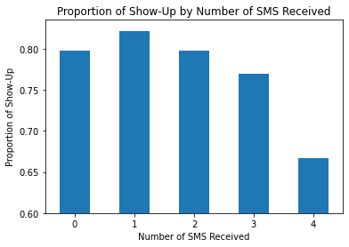

```python
count = df.groupby('sms_received').show_up.value_counts()
total = df.groupby('sms_received').show_up.count()
proportion = count / total
proportion[:, True].plot(kind='bar', ylabel='Proportion of Show-Up',
                         xlabel='Number of SMS Received',
                         title='Proportion of Show-Up by Number of SMS Received',
                         ylim=(0.6, 0.835));
plt.xticks(rotation=0);
```

Looking at the above graph, we are tempted to say that increasing the number of SMS will reduce the likelihood of a patient showing up for the appointment. However, let's see the number of data points for each number of SMS received below.

```python
count.sum(level='sms_received')
```

```
sms_received
0    108282
1      2040
2       183
3        13
4         3
Name: show_up, dtype: int64
```

As you can see above, there are only 13 data points for 3 SMS received, and only 3 data points for 4 SMS received. This means that their proportion count may not be accurate enough, we cannot say any conclusion about them with high confidence. Thus, for this analysis, we'll only see that data whose number of data points is greater than 100, which in this case will be the data for SMS received being 0 to 2. Below we'll replot the bar chart.

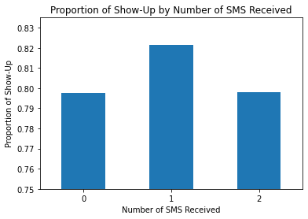

```python
proportion.loc[0:2, True].plot(kind='bar', ylabel='Proportion of Show-Up',
                         xlabel='Number of SMS Received',
                         title='Proportion of Show-Up by Number of SMS Received',
                         ylim=(0.75, 0.835),
                         xticks=[0, 1, 2]);
plt.xticks(rotation=0);
```

Below is to show the exact proportions for the analysis in the next paragraph.

```python
proportion.loc[0:2, True]
```

```
sms_received  show_up
0             True       0.797667
1             True       0.821569
2             True       0.797814
Name: show_up, dtype: float64
```

As you can see in the graph above, we can see that the SMS sent to patient can increase the likelihood of the patient to show up for the appointment only up to 1 SMS. More than that, the effectivity of the SMS reduces. 1 SMS increases the likelihood of patient showing up by 2% (from 79.8% with 0 SMS to 82.2% with 1 SMS). However, when the SMS sent is 2, it doesn't increase the likelihood of the patient showing up (from 79.8% with 0 SMS to 79.8% with 2 SMS).

A possible explanation of this can be that 1 SMS can manage to remind any patient that forgot about their appointment. However, more than 1 SMS, for example 2 SMS in our analysis above, will no longer server to remind patients that forgot about their appointment. 1 SMS is already enough to remind them, and the second SMS is no longer useful. If after 1 SMS the patient still did not show up for the appointment, this means that they actually still remember about the appointment (maybe reminded after the first SMS), but they have decided to not go for the appointment. That is why increasing the number of SMS to the patient does not increase likelihood of the patient to show up for the appointment, because they no longer forget about it, but rather they have decided to not go for the appointment, which in this case more SMS will no longer serve its purpose to remind the patient about the appointment.

From another perspective, if the patient was sent more than 1 SMS, this means the patient did not respond to the first SMS, which either is because: the patient no longer interested in the appointment, or the patient is unable to receive the SMS at all. For both of the reasons mentioned, any more SMS will not be effective anymore in making the patient to show up for the appointment.

### Research Question 2: Does the day of week affect patient no-show rate?

```python
df['appointment_weekday'] = df.appointment_day.dt.weekday
df[['appointment_day', 'appointment_weekday']].head()
```

|  | appointment_day | appointment_weekday |
| --- | --- | --- |
| 0 | 2016-04-29 | 4 |
| 1 | 2016-04-29 | 4 |
| 2 | 2016-04-29 | 4 |
| 3 | 2016-04-29 | 4 |
| 4 | 2016-04-29 | 4 |

Below we'll calculate the proportion of "no-show" for each weekday, e.g. no-show proportion on Mondays, Tuesdays, etc.

```python
show_up_appt_day = df.groupby('appointment_weekday').show_up.value_counts()
show_up_appt_day_total = df.groupby('appointment_weekday').show_up.count()
show_up_appt_day_prop = show_up_appt_day / show_up_appt_day_total
```

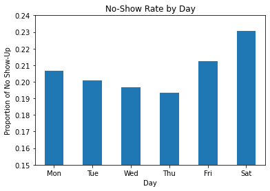

```python
show_up_appt_day_prop.loc[:, False].plot(kind='bar', title='No-Show Rate by Day')
labels = ['Mon', 'Tue', 'Wed', 'Thu', 'Fri', 'Sat']
plt.xticks(ticks=range(6), labels=labels, rotation=0);
plt.ylim(0.15, 0.24);
plt.ylabel('Proportion of No Show-Up');
plt.xlabel('Day');
```

It can be seen above that Saturday has the highest proportion of having no-show, whereas Friday comes as the second highest. We can also see the trend where, in general, the no-show rate decreases from Monday to Thursday, then starts increasing again from Friday to Saturday. There is no record on Sunday, probably due to the hospital having holiday every Sunday.

This phenomenon is not that surprising, as on Mondays people are usually busier to catch up on their work. As they go into the midweek, they'd have settled their business and thus are more free to show up for the hospital appointments. Then there is an increase of no-show on Friday and Saturday, probably due to last minute weekend plans.

### Research Question 3: Does the gap between scheduled date and appointment date affect patient no-show rate?

Below we'll create a new column `schedule_gap_days` which will have the number of days gap between the scheduled day and the appointment day. If the appointment is on the same day as the scheduled day, then the gap will be 0. The column will be of integer values for the count of days.

```python
df['schedule_gap_days'] = (df.appointment_day.dt.date - df.scheduled_day.dt.date).dt.days
df[['scheduled_day', 'appointment_day', 'schedule_gap_days']].tail()
```

|  | scheduled_day | appointment_day | schedule_gap_days |
| --- | --- | --- | --- |
| 110516 | 2016-05-03 09:15:35 | 2016-06-07 | 35 |
| 110517 | 2016-05-03 07:27:33 | 2016-06-07 | 35 |
| 110518 | 2016-04-27 16:03:52 | 2016-06-07 | 41 |
| 110519 | 2016-04-27 15:09:23 | 2016-06-07 | 41 |
| 110520 | 2016-04-27 13:30:56 | 2016-06-07 | 41 |

To be able to analyze the proportions of no-show based on the schedule gap, we'll first categorize the schedule gap based on the 5-number summary statistics of the schedule gap days. Below we'll print the statistics of `schedule_gap_days`.

```python
df.schedule_gap_days.describe()
```

```
count    110521.000000
mean         10.184345
std          15.255153
min           0.000000
25%           0.000000
50%           4.000000
75%          15.000000
max         179.000000
Name: schedule_gap_days, dtype: float64
```

Below code will then do the categorization of `schedule_gap_days` and then put the values in the new column `schedule_gap_category`.

```python
bins = df.schedule_gap_days.describe()[['min', '25%', '50%', '75%', 'max']].values
bins[1] = 0.1 # because the 25% quantile is also 0.0 days, so need to set to small number so that the cut can work
df['schedule_gap_category'] = pd.cut(df.schedule_gap_days, bins=bins, labels=['no_gap', 'short', 'medium', 'long'], right=False)
```

Below we'll calculate and plot the no-show proportion for each schedule gap category.

```python
count = df.groupby('schedule_gap_category').show_up.value_counts()
total = df.groupby('schedule_gap_category').show_up.count()
schedule_gap_showup_prop = count / total
```

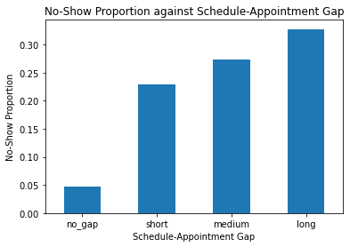

```python
schedule_gap_showup_prop[:, False].plot(kind='bar')
plt.title('No-Show Proportion against Schedule-Appointment Gap')
plt.xlabel('Schedule-Appointment Gap')
plt.ylabel('No-Show Proportion')
plt.xticks(rotation=0);
```

## Conclusions

In summary, here are the findings of this data analysis:

- SMS reminders seem to be only effective at reducing the rate of patient no-show up to 1 SMS. More than 1 SMS, the effect of it on the patient no-show starts to diminish.
- Against day of week, patient no-show rate seems to be decreasing from Monday to Thursday, then starts increasing again from Friday to Saturday, with the highest on Saturday.
- Comparing against the gap between the date when the appointment is made and the actual appointment date, it is found that the longer the gap, the more patient no-show occurs. Even a short gap increases the rate of patient no-show significantly compared to zero days gap.

Do note that this data analysis has limitation where there is no statistical test done, and this is purely just data analysis.